# Project mouse

Litvinov Daniil

14/02/2021

Libraries used:

```r
library(readxl)
library(ggplot2)
library(dplyr)
library(car)
library(multcomp)
library(GGally)
library(corrplot)
library(ggcorrplot)
library(vegan)
library(factoextra)
library(scatterplot3d)
library(rgl)
```

# 1 Introduction

In this work I wiil use data from article about the effect of Down syndrome on different proteins production. Data for this project can be found [here](https://archive.ics.uci.edu/ml/datasets/Mice+Protein+Expression#).

*Goal* – conduct EDA, make a few linear models to predict production level of some proteins and also make PCA.

In additional part of this project I will analyze differential expressing genes.

# 2 Data description

## 2.1 Data description

```r
mouse_data <- read_xls('Data/Data_Cortex_Nuclear.xls')
str(mouse_data)
```

```
## tibble [1,080 × 82] (S3: tbl_df/tbl/data.frame)
##  $ MouseID        : chr [1:1080] "309_1" "309_2" "309_3" "309_4" ...
##  $ DYRK1A_N       : num [1:1080] 0.504 0.515 0.509 0.442 0.435 ...
##  $ ITSN1_N        : num [1:1080] 0.747 0.689 0.73 0.617 0.617 ...
##  $ BDNF_N         : num [1:1080] 0.43 0.412 0.418 0.359 0.359 ...
##  $ NR1_N          : num [1:1080] 2.82 2.79 2.69 2.47 2.37 ...
##  $ NR2A_N         : num [1:1080] 5.99 5.69 5.62 4.98 4.72 ...
##  $ pAKT_N         : num [1:1080] 0.219 0.212 0.209 0.223 0.213 ...
##  $ pBRAF_N        : num [1:1080] 0.178 0.173 0.176 0.176 0.174 ...
##  $ pCAMKII_N      : num [1:1080] 2.37 2.29 2.28 2.15 2.13 ...
##  $ pCREB_N        : num [1:1080] 0.232 0.227 0.23 0.207 0.192 ...
##  $ pELK_N         : num [1:1080] 1.75 1.6 1.56 1.6 1.5 ...
##  $ pERK_N         : num [1:1080] 0.688 0.695 0.677 0.583 0.551 ...
##  $ pJNK_N         : num [1:1080] 0.306 0.299 0.291 0.297 0.287 ...
##  $ PKCA_N         : num [1:1080] 0.403 0.386 0.381 0.377 0.364 ...
```

[output cut: 68 more lines]

You can see that MouseID contain information both about mouse id and about technical repetition. To create new variable **id** in data I made this function:

```r
make_id <- function(data){
  f <- function(x){
    list_of_letters <- strsplit(x, '')
    under_index <- which(list_of_letters[[1]] == '_')
    return(substr(x, 1, under_index - 1))
  }
  ids <- unlist(lapply(data, f))
  return(ids)
}
```

This function takes one argument (column) and return vector, consisting of first parts of strings till "_". So we can get information only about mouse id.

```r
mouse_data$id <- make_id(mouse_data$MouseID)
```

There are 72 mice in experiment.

It may be a good idea to make some of our variables as factors:

```r
mouse_data$Genotype <- as.factor(mouse_data$Genotype)
mouse_data$Treatment <- as.factor(mouse_data$Treatment)
mouse_data$Behavior <- as.factor(mouse_data$Behavior)
mouse_data$class <- as.factor(mouse_data$class)
classes <- levels(mouse_data$class)
```

we can distinguish 8 groups by variable **class**.

```r
class_pivot_count <- mouse_data %>%
                      group_by(class) %>%
                      summarise(count = n() / 15)
treat_pivot_count <- mouse_data %>%
                     group_by(Treatment) %>%
                     summarise(count = n() / 15)
genotype_pivot_count <- mouse_data %>%
                        group_by(Genotype) %>%
                        summarise(count = n() / 15)
behavior_pivot_count <- mouse_data %>%
                        group_by(Behavior) %>%
                        summarise(count = n() / 15)
```

This function helps to create barplots of distribution of mice in groups based on different variables:

```r
group_distr_col <- function(data, x, y = 'count'){
  ggplot(data, aes(x = list(data[x][[1]])[[1]], y = list(data[y][[1]])[[1]])) +
    geom_col(fill = '#FDC65E') +
    theme(plot.title = element_text(hjust = 0.5)) +
    xlab(paste0('Groups based on variable ', x)) +
    ylab('Number of mice') +
    ggtitle(paste0('Distribution of mice in groups based on variable ', x))
}
```

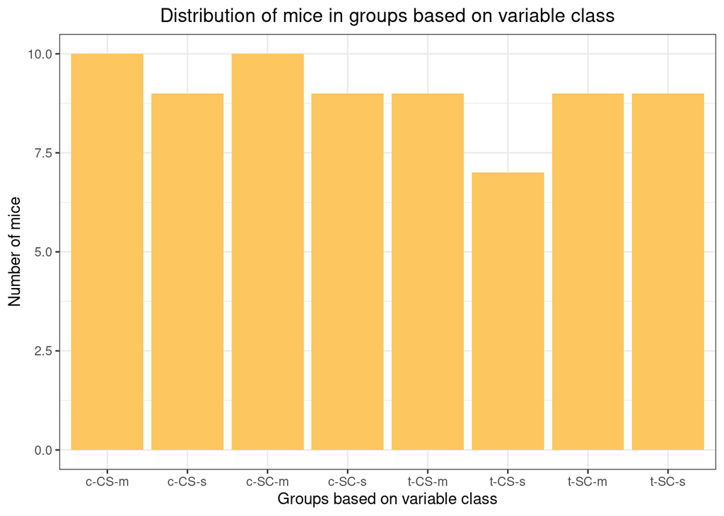

```r
group_distr_col(class_pivot_count, 'class')
```

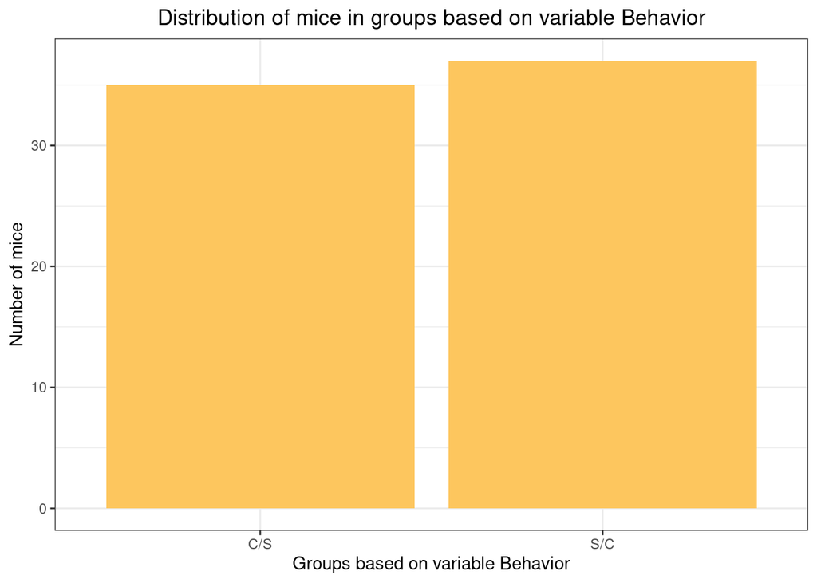

```r
group_distr_col(behavior_pivot_count, 'Behavior')
```

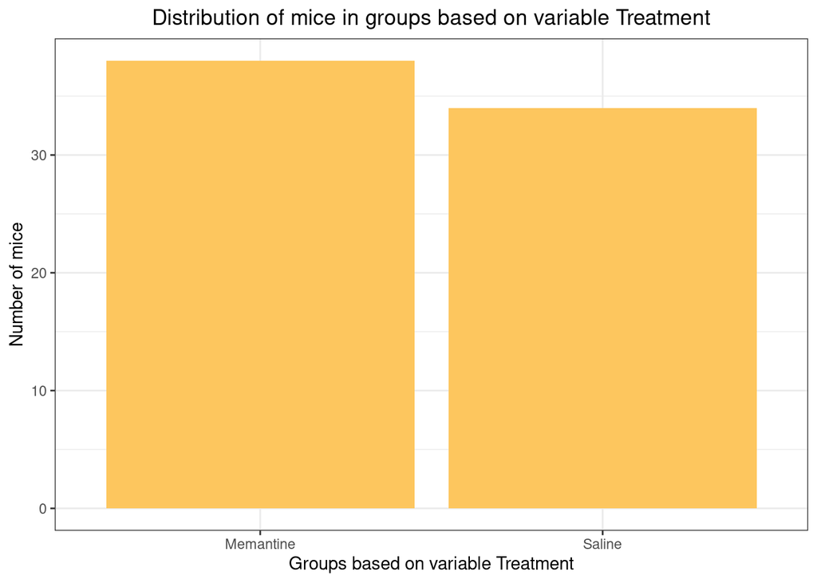

```r
group_distr_col(treat_pivot_count, 'Treatment')
```

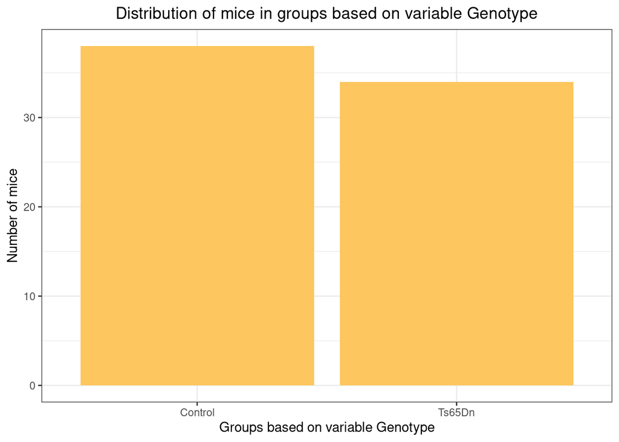

```r
group_distr_col(genotype_pivot_count, 'Genotype')
```

We can see that the groups are not quite balanced and ANOVA that we plan to apply further may be less resistant to violation of the conditions of applicability.

Classes:

- c-CS-s: control mice, stimulated to learn, injected with saline (9 mice)
- c-CS-m: control mice, stimulated to learn, injected with memantine (10 mice)
- c-SC-s: control mice, not stimulated to learn, injected with saline (9 mice)
- c-SC-m: control mice, not stimulated to learn, injected with memantine (10 mice)
- t-CS-s: trisomy mice, stimulated to learn, injected with saline (7 mice)
- t-CS-m: trisomy mice, stimulated to learn, injected with memantine (9 mice)
- t-SC-s: trisomy mice, not stimulated to learn, injected with saline (9 mice)
- t-SC-m: trisomy mice, not stimulated to learn, injected with memantine (9 mice)

## 2.2 Making data tidy

Now there is a time to deal with NA. There are 1396 missing values in our dataset.

It is interesting to check distribution of NAs in different groups. May be some proteins just were not expressed in certain conditions.

```r
pivot_na_data
```

| class | DYRK1A_N | ITSN1_N | BDNF_N | NR1_N | NR2A_N | pAKT_N | pBRAF_N | pCAMKII_N | pCREB_N | pELK_N | pERK_N | pJNK_N | PKCA_N | pMEK_N | pNR1_N | pNR2A_N | pNR2B_N | pPKCAB_N | pRSK_N | AKT_N | BRAF_N | CAMKII_N | CREB_N | ELK_N | ERK_N | GSK3B_N | JNK_N | MEK_N | TRKA_N | … |
| --- | --- | --- | --- | --- | --- | --- | --- | --- | --- | --- | --- | --- | --- | --- | --- | --- | --- | --- | --- | --- | --- | --- | --- | --- | --- | --- | --- | --- | --- | --- |
| c-CS-m | 0 | 0 | 0 | 0 | 0 | 0 | 0 | 0 | 0 | 0 | 0 | 0 | 0 | 0 | 0 | 0 | 0 | 0 | 0 | 0 | 0 | 0 | 0 | 0 | 0 | 0 | 0 | 0 | 0 | … |
| c-CS-s | 0 | 0 | 0 | 0 | 0 | 0 | 0 | 0 | 0 | 0 | 0 | 0 | 0 | 0 | 0 | 0 | 0 | 0 | 0 | 0 | 0 | 0 | 0 | 15 | 0 | 0 | 0 | 4 | 0 | … |
| c-SC-m | 0 | 0 | 0 | 0 | 0 | 0 | 0 | 0 | 0 | 0 | 0 | 0 | 0 | 0 | 0 | 0 | 0 | 0 | 0 | 0 | 0 | 0 | 0 | 0 | 0 | 0 | 0 | 0 | 0 | … |
| c-SC-s | 0 | 0 | 0 | 0 | 0 | 0 | 0 | 0 | 0 | 0 | 0 | 0 | 0 | 0 | 0 | 0 | 0 | 0 | 0 | 0 | 0 | 0 | 0 | 0 | 0 | 0 | 0 | 0 | 0 | … |
| t-CS-m | 0 | 0 | 0 | 0 | 0 | 0 | 0 | 0 | 0 | 0 | 0 | 0 | 0 | 0 | 0 | 0 | 0 | 0 | 0 | 0 | 0 | 0 | 0 | 0 | 0 | 0 | 0 | 0 | 0 | … |
| t-CS-s | 0 | 0 | 0 | 0 | 0 | 0 | 0 | 0 | 0 | 0 | 0 | 0 | 0 | 0 | 0 | 0 | 0 | 0 | 0 | 0 | 0 | 0 | 0 | 0 | 0 | 0 | 0 | 0 | 0 | … |
| t-SC-m | 0 | 0 | 0 | 0 | 0 | 0 | 0 | 0 | 0 | 0 | 0 | 0 | 0 | 0 | 0 | 0 | 0 | 0 | 0 | 0 | 0 | 0 | 0 | 0 | 0 | 0 | 0 | 0 | 0 | … |
| t-SC-s | 3 | 3 | 3 | 3 | 3 | 3 | 3 | 3 | 3 | 3 | 3 | 3 | 3 | 3 | 3 | 3 | 3 | 3 | 3 | 3 | 3 | 3 | 3 | 3 | 3 | 3 | 3 | 3 | 3 | … |

Since there are quite a few missing values in the data, I will replace them with group means (class variable).

```r
na_2_mean <- function(df){
for (cols in colnames(df)) {
  if (cols %in% names(df[,sapply(df, is.numeric)])) {
    df <- df %>% mutate(!!cols := replace(!!rlang::sym(cols), is.na(!!rlang::sym(cols)), mean(!!rlang::sym(cols), na.rm=TRUE)))
  }
  else {

    df <- df %>% mutate(!!cols := replace(!!rlang::sym(cols), !!rlang::sym(cols) == "", getmode(!!rlang::sym(cols))))
  }
}
 return(df)
}

mouse_data_wo_na <- cbind(mouse_data$MouseID,
                           mouse_data$id,
                           mouse_data$class,
                           mouse_data$Behavior,
                           mouse_data$Treatment,
                           mouse_data$Genotype,
                           rbind(na_2_mean(c_CS_m),
                           na_2_mean(c_CS_s),
                           na_2_mean(c_SC_m),
                           na_2_mean(c_SC_s),
                           na_2_mean(t_CS_m),
                           na_2_mean(t_CS_s),
                           na_2_mean(t_SC_m),
                           na_2_mean(t_SC_s)))

colnames(mouse_data_wo_na)[1:6] <- c('MouseID',
                                     'id',
                                     'class',
                                     'Behavior',
                                     'Treatment',
                                     'Genotype')
```

Let’s do a little check to see if NAs were really replaced by group means.

```r
na_2_mean(c_CS_s)[is.na(c_CS_s$H3MeK4_N), ]$H3MeK4_N[1] == mean(c_CS_s$H3MeK4_N, na.rm = T)
```

```
## [1] TRUE
```

It looks nice so I can go to the next analysis.

# 3 BDNF_N production level depending on the class

I am going to conduct ANOVA in this case:

```r
bdnf_mod <- lm(BDNF_N ~ class, data = mouse_data_wo_na)
av_bdn_mod <- Anova(bdnf_mod)
av_bdn_mod
```

|  | Sum Sq | Df | F value | Pr(>F) |
| --- | --- | --- | --- | --- |
| class | 0.3054605 | 7 | 20.17472 | 1.504542e-25 |
| Residuals | 2.3186991 | 1072 | NA | NA |

We can see that **class** is a significant predictor. So we can assume that there are some differences in the BDNF_N production level depending on the class in experiment. But but first we have to check the conditions of applicability and conduct post-hoc tests.

## 3.1 Checking the applicability conditions

```r
bdnf_mod_diag <- fortify(bdnf_mod)
```

**Graph of Cook’s distances**

There are several heuristics for calculating threshold for Cook’s distances. It can be just 2, 3 * mean(y) or $\frac4n$, where n is number of samples. Here I am going to use third.

```r
cook_threshold <- 4 / nrow(mouse_data_wo_na)
```

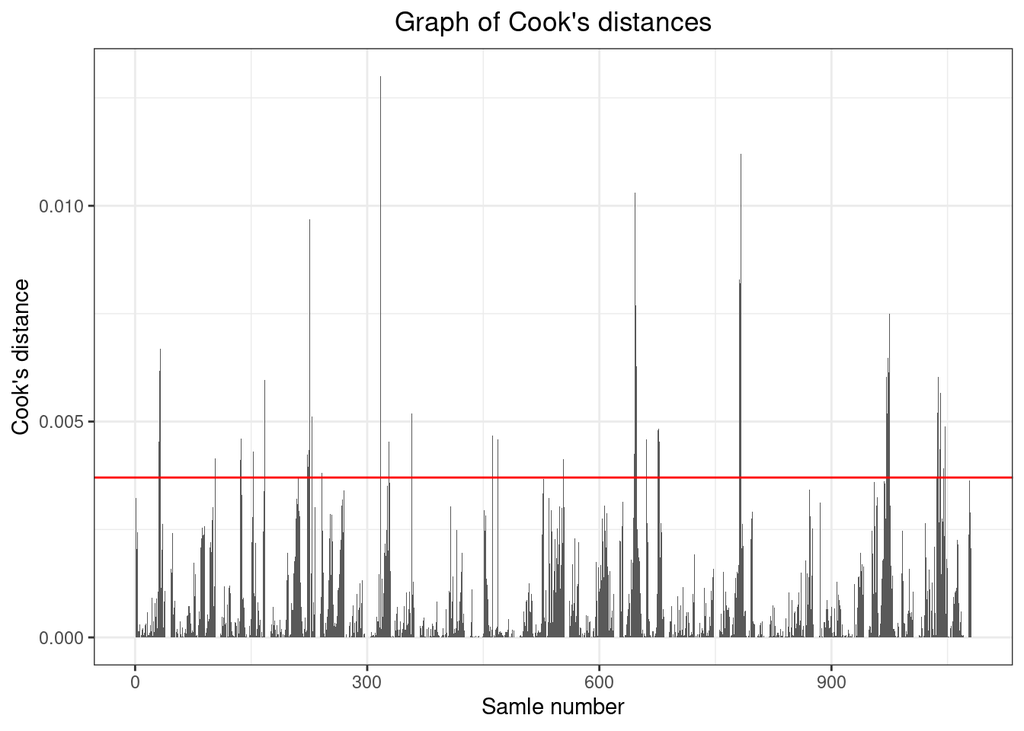

```r
ggplot(bdnf_mod_diag, aes(x = 1:nrow(bdnf_mod_diag), y = .cooksd)) +
  geom_bar(stat = 'identity') +
  geom_hline(yintercept = cook_threshold, color = "red") +
  xlab("Samle number") +
  ylab("Cook's distance") +
  ggtitle("Graph of Cook's distances") +
  theme(plot.title = element_text(hjust = 0.5))
```

There are 46 samples which are a little bit bigger than threshold, but it is okey and I will not drop these samples from model.

**Model residues**

Residuals plots show that there are quite a few poorly predicted values, but no particular pattern is observed, also the median value of residuals in different classes is approximately the same and is close to zero.

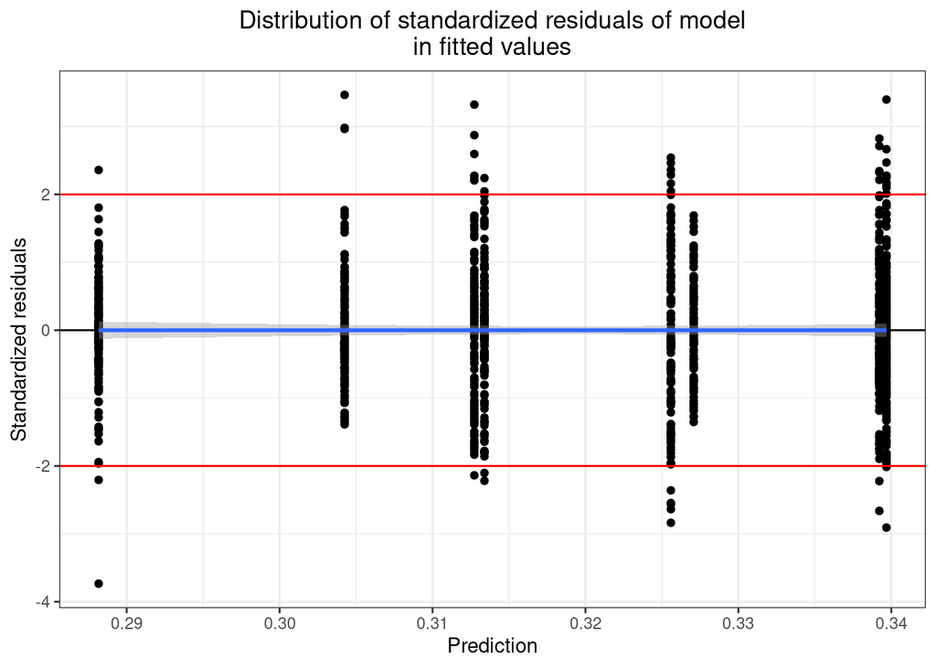

```r
ggplot(data = bdnf_mod_diag, aes(x = .fitted, y = .stdresid)) +
  geom_point() +
  geom_hline(yintercept = 0) +
  geom_smooth(method = "lm") +
  geom_hline(yintercept = 2, color = "red") +
  geom_hline(yintercept = -2, color = "red") +
  xlab('Prediction') +
  ylab('Standardized residuals') +
  ggtitle('Distribution of standardized residuals of model\nin fitted values') +
  theme(plot.title = element_text(hjust = 0.5))
```

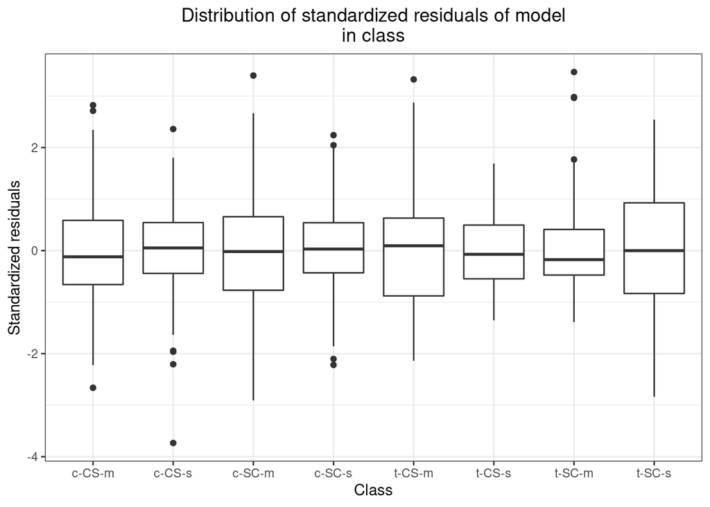

```r
ggplot(bdnf_mod_diag, aes(x = class, y = .stdresid)) +
  geom_boxplot() +
  theme(plot.title = element_text(hjust = 0.5)) +
  xlab('Class') +
  ylab('Standardized residuals') +
  ggtitle('Distribution of standardized residuals of model\nin class')
```

**Normal distribution of model residuals**

Despite the fact that we cannot name the distribution of the residuals of the model like a normal, we may try to apply ANOVA, since qqplot looks good and other conditions generally applicable and also we have lots of samples that is good for ANOVA.

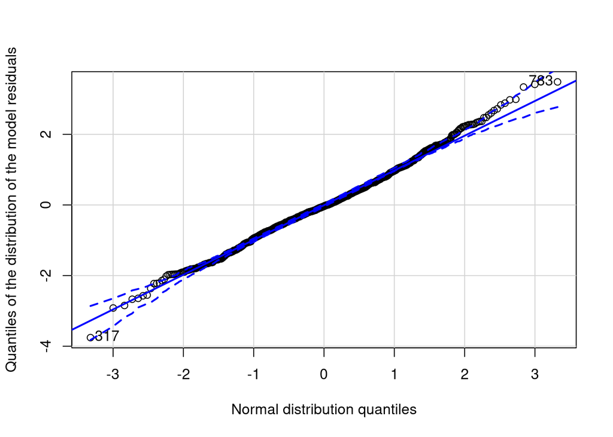

```
## [1] 317 783
```

```r
qqPlot(bdnf_mod, xlab = 'Normal distribution quantiles', ylab = 'Quantiles of the distribution of the model residuals')
```

```r
shapiro.test(bdnf_mod_diag$.resid)
```

```
##
##  Shapiro-Wilk normality test
##
## data:  bdnf_mod_diag$.resid
## W = 0.99534, p-value = 0.002166
```

**Post-hoc tests**

Here I will use Tukey post-hoc test:

```r
res_tukey <- glht(bdnf_mod, linfct = mcp(class = 'Tukey'))
summary(res_tukey)
```

```
##
##   Simultaneous Tests for General Linear Hypotheses
##
## Multiple Comparisons of Means: Tukey Contrasts
##
##
## Fit: lm(formula = BDNF_N ~ class, data = mouse_data_wo_na)
##
## Linear Hypotheses:
##                        Estimate Std. Error t value Pr(>|t|)
## c-CS-s - c-CS-m == 0 -0.0510532  0.0055174  -9.253  < 0.001 ***
## c-SC-m - c-CS-m == 0  0.0004643  0.0053702   0.086  1.00000
## c-SC-s - c-CS-m == 0 -0.0258249  0.0055174  -4.681  < 0.001 ***
## t-CS-m - c-CS-m == 0 -0.0264852  0.0055174  -4.800  < 0.001 ***
## t-CS-s - c-CS-m == 0 -0.0121377  0.0059177  -2.051  0.44698
## t-SC-m - c-CS-m == 0 -0.0349691  0.0055174  -6.338  < 0.001 ***
## t-SC-s - c-CS-m == 0 -0.0136310  0.0055174  -2.471  0.20856
## c-SC-m - c-CS-s == 0  0.0515175  0.0055174   9.337  < 0.001 ***
## c-SC-s - c-CS-s == 0  0.0252283  0.0056607   4.457  < 0.001 ***
## t-CS-m - c-CS-s == 0  0.0245680  0.0056607   4.340  < 0.001 ***
## t-CS-s - c-CS-s == 0  0.0389155  0.0060516   6.431  < 0.001 ***
## t-SC-m - c-CS-s == 0  0.0160841  0.0056607   2.841  0.08599 .
## t-SC-s - c-CS-s == 0  0.0374222  0.0056607   6.611  < 0.001 ***
## c-SC-s - c-SC-m == 0 -0.0262892  0.0055174  -4.765  < 0.001 ***
## t-CS-m - c-SC-m == 0 -0.0269495  0.0055174  -4.884  < 0.001 ***
## t-CS-s - c-SC-m == 0 -0.0126021  0.0059177  -2.130  0.39591
## t-SC-m - c-SC-m == 0 -0.0354334  0.0055174  -6.422  < 0.001 ***
## t-SC-s - c-SC-m == 0 -0.0140954  0.0055174  -2.555  0.17341
## t-CS-m - c-SC-s == 0 -0.0006603  0.0056607  -0.117  1.00000
## t-CS-s - c-SC-s == 0  0.0136872  0.0060516   2.262  0.31526
## t-SC-m - c-SC-s == 0 -0.0091442  0.0056607  -1.615  0.74077
## t-SC-s - c-SC-s == 0  0.0121939  0.0056607   2.154  0.38047
## t-CS-s - t-CS-m == 0  0.0143475  0.0060516   2.371  0.25644
## t-SC-m - t-CS-m == 0 -0.0084839  0.0056607  -1.499  0.80803
## t-SC-s - t-CS-m == 0  0.0128542  0.0056607   2.271  0.31023
## t-SC-m - t-CS-s == 0 -0.0228314  0.0060516  -3.773  0.00427 **
## t-SC-s - t-CS-s == 0 -0.0014933  0.0060516  -0.247  1.00000
## t-SC-s - t-SC-m == 0  0.0213381  0.0056607   3.769  0.00424 **
## ---
## Signif. codes:  0 '***' 0.001 '**' 0.01 '*' 0.05 '.' 0.1 ' ' 1
## (Adjusted p values reported -- single-step method)
```

**Post-hoc tests visualization**

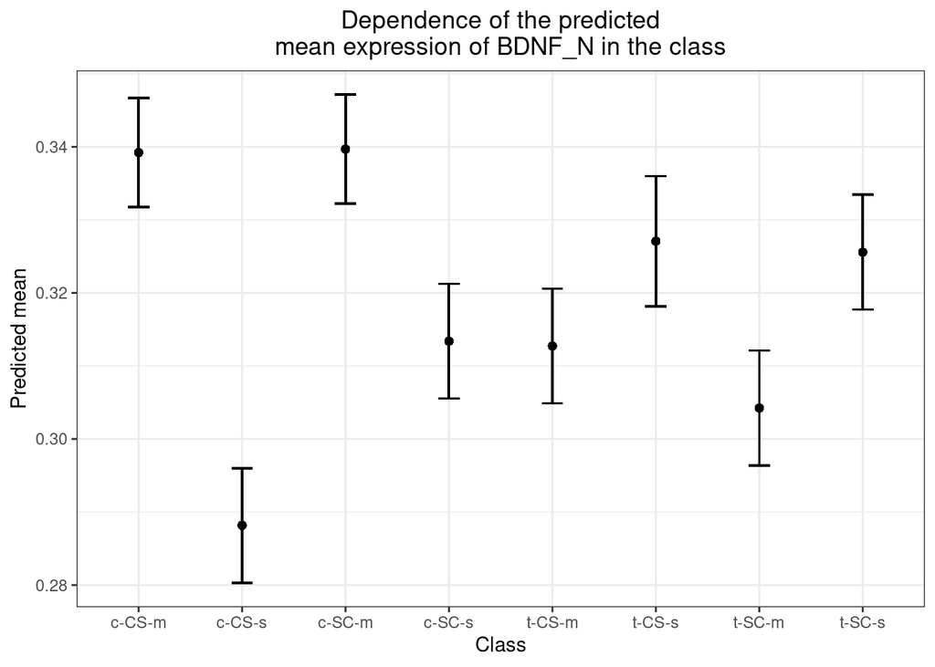

```r
data <-  expand.grid(class = mouse_data_wo_na$class)
data <- data.frame(data,
                   predict(bdnf_mod, newdata = data, interval = 'confidence'))
pos <- position_dodge(width = 0.2)
gg_linep <- ggplot(data, aes(x = class, y = fit,
                             ymin = lwr, ymax = upr)) +
  geom_point(position = pos) +
  geom_errorbar(position = pos, width = 0.2) +
  theme(plot.title = element_text(hjust = 0.5)) +
  xlab('Class') +
  ylab('Predicted mean') +
  ggtitle('Dependence of the predicted\nmean expression of BDNF_N in the class')
gg_linep
```

It can be seen that there is a significant dependence of the BDNF_N production in the class in the experiment.